# XH-pi frequency vs resolution

Emma Rand

22/08/2019

These data have 7306 structures.

The linear model of `freq_per_100 ~ resolution` has the equation: freq_per_100 = 10.0917671 -1.8706521 * resolution

The sample size makes it highly significant but the R squared value is low (0.0475239) i.e., very little of the variation in the number of interactions can be explained by the resolution.

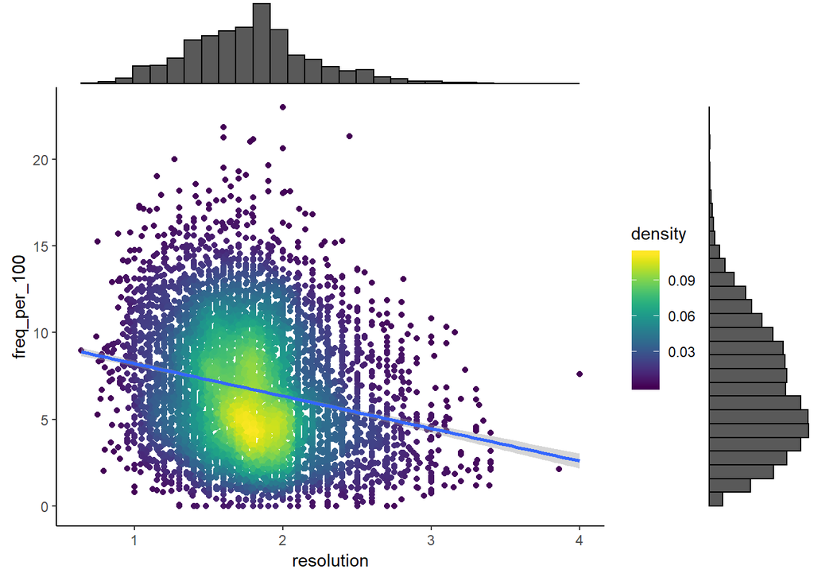

When filtering the data for resolutions less than 1.5A there are 1708 structures and the linear model of `freq_per_100 ~ resolution` has the equation: freq_per_100 = 9.5570776 -1.4576012 * resolution

which is still significant with an R squared value of (0.0043161).

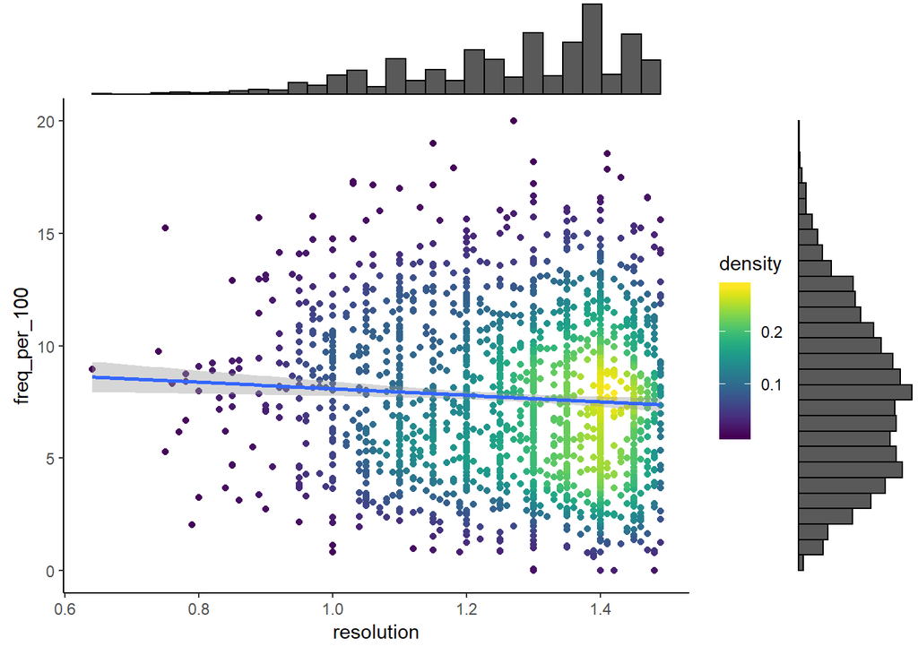

At a cut-off resolution of 1.3A there are 777 and the relationship disappears.

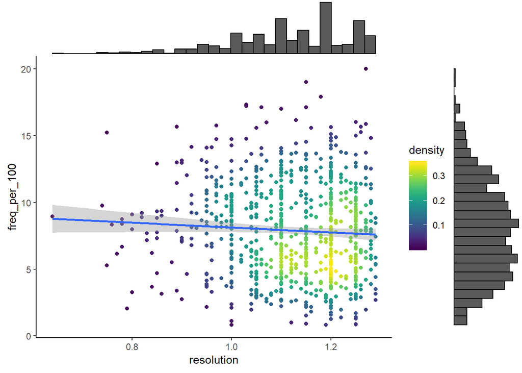

# 1 Moving Window regression

Regressions were carried out for a moving window of 500 observations, i.e., the size of resolution window is dependent on the number of observations

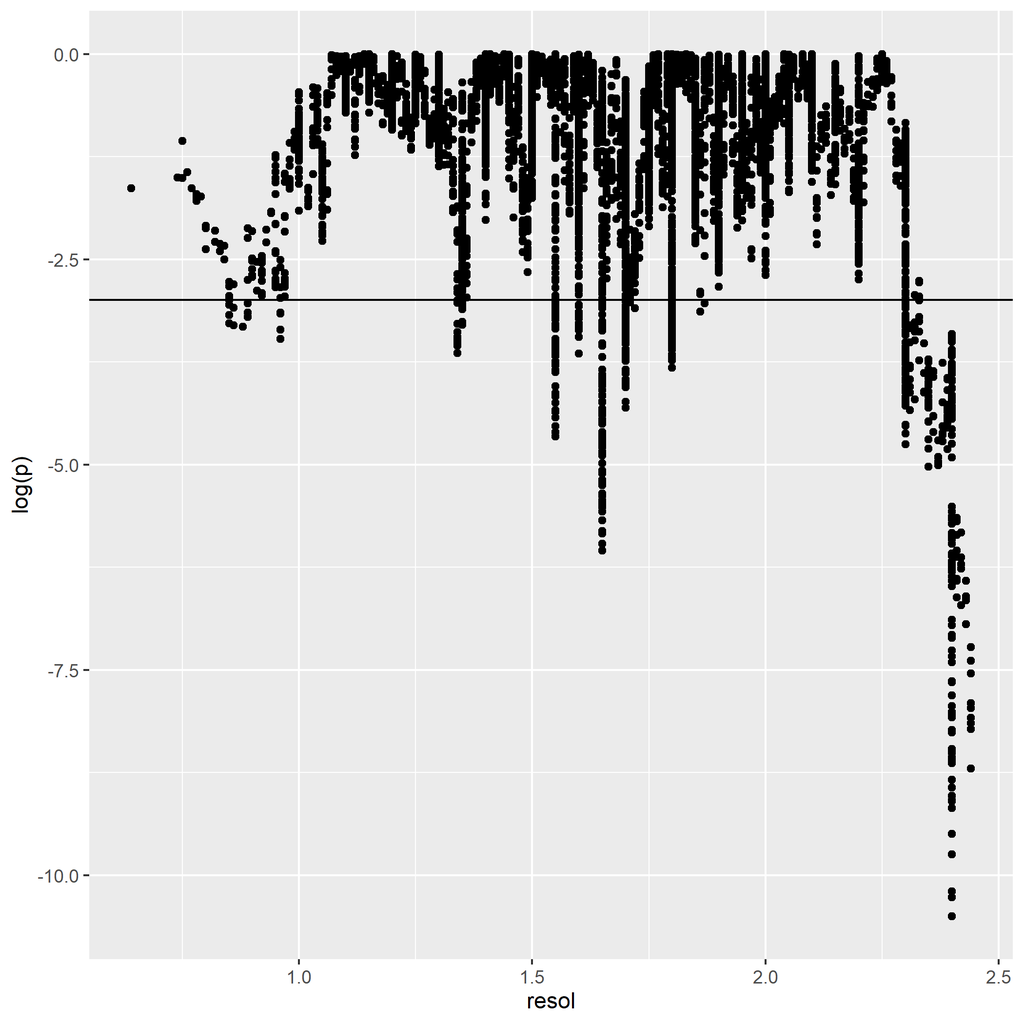

## 1.2 Fixed resolution window

- slope of the linear regression
- standard error on the slope
- p value obtained from testing the slope against zero
- False discovery rate - the p value adjusted by the Benjamini & Hochberg method.

Size of the population available in each sample window. The red line indicates the size of the samples being drawn: 50

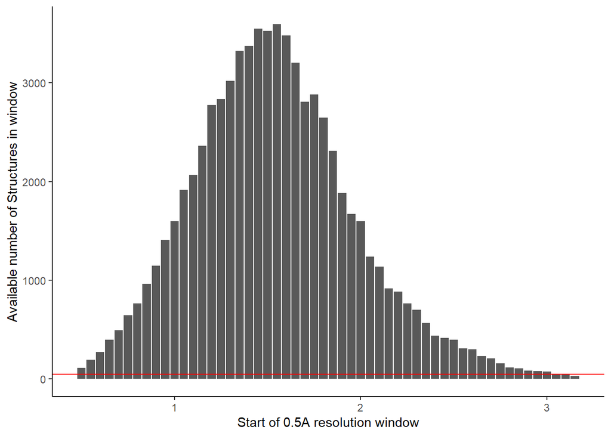

There are more negative than positive slopes and the large majority of the significant slopes are negative (p < 0.05).

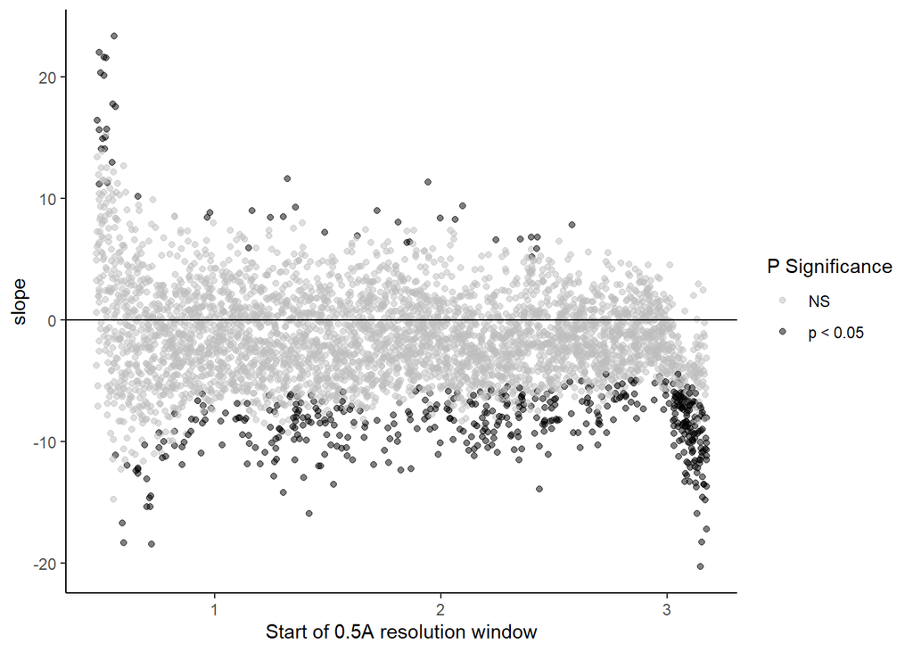

However, it is not the case that significant negative slopes start appearing at some resolution. A cut-off is not obvious.

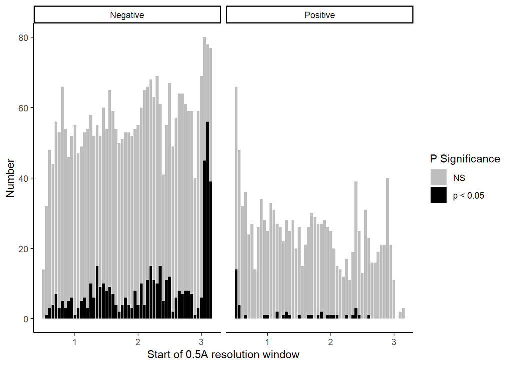

(remember these are random samples and the outcomes with differ at little each time)

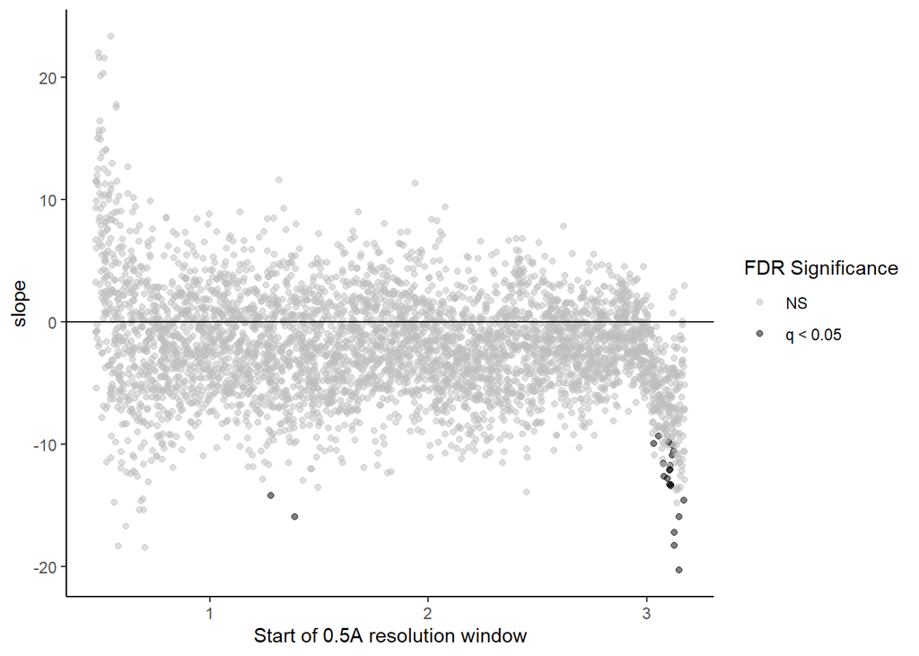